# Non-parametric Analysis

# Packages in this presentation

```r
library(broom)
library(dplyr)
library(ggplot2)
library(lubridate)
library(magrittr)
library(quantreg)
library(reshape2)
library(stringr)
library(tidyr)
```

# What is it?

Nonparametric methods are procedures whose validity does not depend on rigid assumptions. (Daniel, Applied Nonparametric Statistics, 1990)

The assumptions of such procedures may be as general as:

- The data are nominal
- The data are ordinal

Often times, one of these is the primary assumption.

# Why use it?

- Sample sizes may be too small to confirm approximate normality
- Sample sizes may be too small to apply central limit theorem
- Research question does not involve sample means
- Not interested in evaluating assumptions

# So how different is it?

| Parametric Test | Non Parametric Test |
| --- | --- |
| Mean (Centrality statistic) | Median (Centrality statistic) |
| Variance (dispersion statistic) | (dispersion often not quantified) |
| One sample z-test of proportions | Binomial Test |
| Two Sample z-test of proportions | Chi-square / Fisher’s Test |
| One sample t-test | Sign Test, Wilcoxon’s Signed Rank Test (sort of) |
| Two sample t-test | Wilcoxon’s Rank Sum Test (sort of) AKA Mann-Whitney |
| F Test of Variances | Ansari Bradley Test |
| One way ANOVA | Kruskal-Wallis Analysis of Ranks |
| Two way ANOVA | Friedman’s Test |
| Pearson’s correlation | Spearmans’ correlation / Kendall’s tau |
| Linear Regression | Quantile Regression |

In short–not very!

# Approaching Non-parametric analysis

Traditional statistics courses focus on parametric methods, and we often end up loooking toward non-parametric procedures as a last resort.

1. Collect sample
2. Exploratory Data Analysis
3. Check assumptions of parametric analysis
4. Use Non-parametric if you have to.

# Approaching Non-parametric analysis (Example)

```r
# 1. Collect sample
Ex1 <- data.frame(group = rep(c("X", "Y"), times = c(17, 10)),
                  subject = c(1:17, 1:10),
                  score = c(11.9, 11.7, 9.5, 9.4, 8.7, 8.2, 7.7,
                            7.4, 7.4, 7.1, 6.9, 6.8, 6.3,
                            5.0, 4.2, 4.1, 2.2, 6.6, 5.8, 5.4,
                            5.1, 5.0, 4.3, 3.9, 3.3, 2.4, 1.7))

#2. Exploratory Data Analysis
Ex1 %>%
  group_by(group) %>%
  summarise(mean = mean(score),
            median = median(score),
            sd = sd(score),
            range_sd = diff(range(score)) / 4,
            range = diff(range(score)),
            min = min(score),
            p25 = quantile(score, probs = 0.25),
            p75 = quantile(score, probs = 0.75),
            max = max(score))
```

```
## # A tibble: 2 x 10
##    group     mean median       sd range_sd range   min   p25   p75   max
##   <fctr>    <dbl>  <dbl>    <dbl>    <dbl> <dbl> <dbl> <dbl> <dbl> <dbl>
## 1      X 7.323529   7.40 2.565524    2.425   9.7   2.2  6.30 8.700  11.9
## 2      Y 4.350000   4.65 1.541464    1.225   4.9   1.7  3.45 5.325   6.6
```

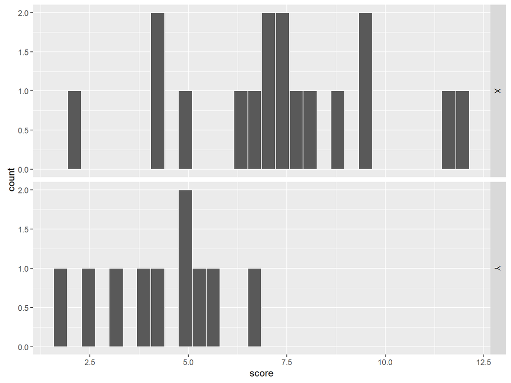

```r
#2. Check assumptions for parametric analysis
ggplot(data = Ex1,
       mapping = aes(x = score)) +
  geom_histogram(color = "white") +
  facet_grid(group ~ .)
```

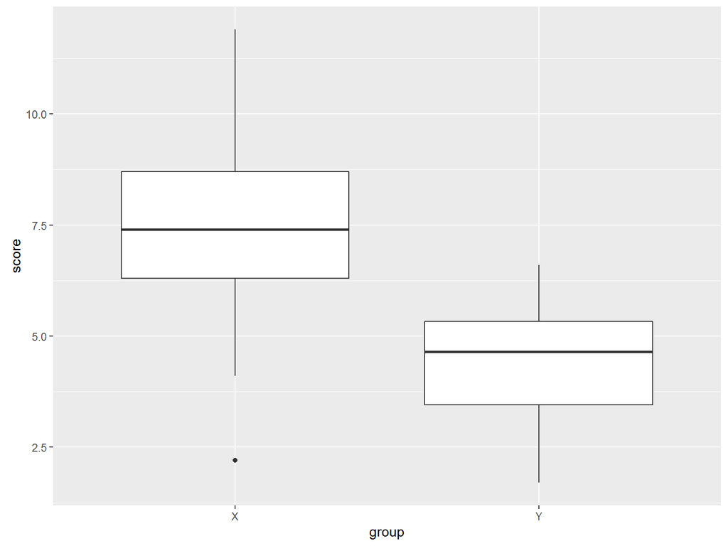

```r
ggplot(data = Ex1,
       mapping = aes(x = group,
                     y = score)) +
  geom_boxplot()
```

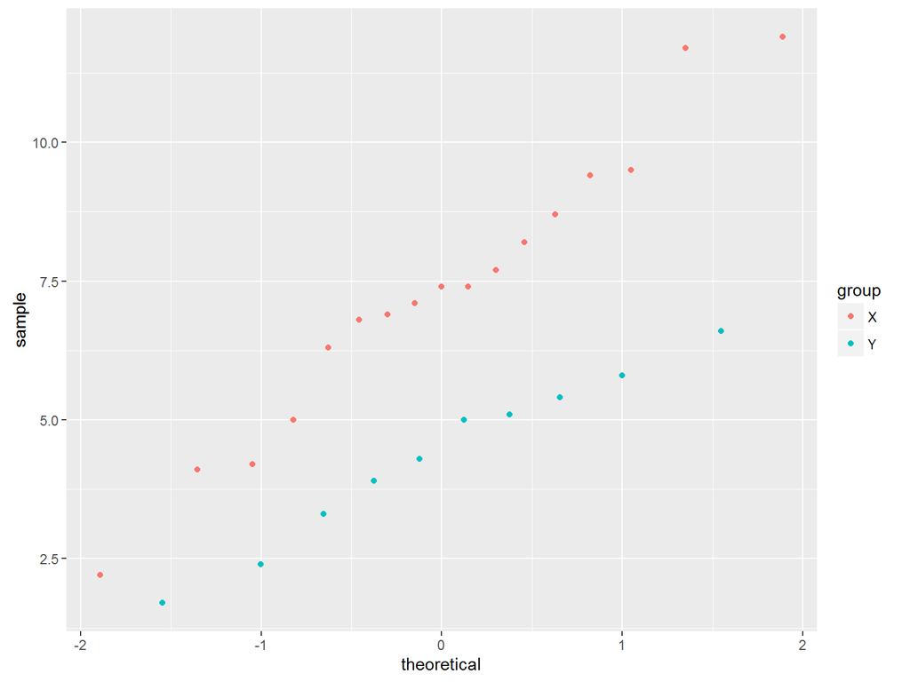

```r
ggplot(data = Ex1,
       mapping = aes(sample = score,
                     colour = group)) +
  stat_qq()
```

# Approaching Non-parametric analysis (revisited)

Traditional statistics courses focus on parametric methods, and we often end up loooking toward non-parametric procedures as a last resort.

1. Collect sample
2. Exploratory Data Analysis
3. Check assumptions of parametric analysis
4. Use Non-parametric if you have to.

# Approaching Non-parametric analysis (revisited)

Traditional statistics courses focus on parametric methods, and we often end up loooking toward non-parametric procedures as a last resort.

1. Collect sample
2. Exploratory Data Analysis
3. Check assumptions of parametric analysis
4. Use Non-parametric if you have to.

This is the wrong way to think about non-parametric methods

# Approaching Non-parametric analysis (corrected)

1. Collect sample
2. Exploratory Data Analysis
3. Is there any reason *not* to use non-parametric methods?
4. Check assumptions of parametric analysis
5. Use parametric methods if it benefits you

# Comparing the Results

```r
t.test(score ~ group, data = Ex1) %>%
tidy()
```

```
##   estimate estimate1 estimate2 statistic      p.value parameter conf.low
## 1 2.973529  7.323529      4.35  3.761905 0.0009128345  24.95532 1.345457
##   conf.high                  method alternative
## 1  4.601602 Welch Two Sample t-test   two.sided
```

```r
wilcox.test(score ~ group, data = Ex1) %>%
tidy()
```

```
##   statistic     p.value                                            method
## 1     143.5 0.003579187 Wilcoxon rank sum test with continuity correction
##   alternative
## 1   two.sided
```

# Interpreting the results

```r
t.test(score ~ group, data = Ex1) %>%
tidy()
```

```
##   estimate estimate1 estimate2 statistic      p.value parameter conf.low
## 1 2.973529  7.323529      4.35  3.761905 0.0009128345  24.95532 1.345457
##   conf.high                  method alternative
## 1  4.601602 Welch Two Sample t-test   two.sided
```

There is evidence to suggest that the mean response in Group X is larger than the mean response in Group Y.

```r
wilcox.test(score ~ group, data = Ex1) %>%
tidy()
```

```
##   statistic     p.value                                            method
## 1     143.5 0.003579187 Wilcoxon rank sum test with continuity correction
##   alternative
## 1   two.sided
```

#### Wrong (Usually):

There is evidence to suggest that the median response in Group X is larger than the median response in Group Y.

(This only true when the X and Y distributions have the same shape, better to just avoid saying this)

#### Correct (always):

There is evidence to suggest that the response in Group X is typically larger than the response in Group Y.

# Example: Test of one centrality parameter

```r
Ex2 <- data.frame(subject = 1:11,
                  time = c(1.80, 3.30, 5.65, 2.25, 2.50, 3.50, 2.75,
                           3.25, 3.10, 2.70, 3.00))
```

$$H_0: Center = 3.5$$
$$H_a: Center \neq 3.5$$

#### Exploratory Data Analysis

```r
Ex2 %>%
  summarise(mean = mean(time),
            median = median(time),
            sd = sd(time),
            range_sd = diff(range(time)) / 4,
            range = diff(range(time)),
            min = min(time),
            p25 = quantile(time, probs = 0.25),
            p75 = quantile(time, probs = 0.75),
            max = max(time))
```

```
##       mean median        sd range_sd range min p25   p75  max
## 1 3.072727      3 0.9890307   0.9625  3.85 1.8 2.6 3.275 5.65
```

```r
t.test(Ex2[["time"]], mu = 3.5) %>% tidy()
```

```
##   estimate statistic   p.value parameter conf.low conf.high
## 1 3.072727  -1.43282 0.1824214        10 2.408287  3.737167
##              method alternative
## 1 One Sample t-test   two.sided
```

```r
mutate(Ex2, high = time >= 3.50) %>%
  group_by(high) %>%
  summarise(freq = n())
```

```
## # A tibble: 2 x 2
##    high  freq
##   <lgl> <int>
## 1 FALSE     9
## 2  TRUE     2
```

```r
binom.test(x = 2, n = 11)
```

```
##
##  Exact binomial test
##
## data:  2 and 11
## number of successes = 2, number of trials = 11, p-value = 0.06543
## alternative hypothesis: true probability of success is not equal to 0.5
## 95 percent confidence interval:
##  0.0228312 0.5177559
## sample estimates:
## probability of success
##              0.1818182
```

# Correlation

Pearson’s correlation coefficient assumptions:

1. sample pairs are independent and identically distributed and
2. follow a bivariate normal distribution

# Correlation

Pearson’s correlation coefficient assumptions:

1. sample pairs are independent and identically distributed and
2. follow a bivariate normal distribution

The second assumption is a *big* assumption, and there’s good reason to believe it doesn’t happen a lot.

# Correlation

Spearman’s correlation assumptions:

1. X and Y have some bivariate distribution.
2. X values can be ranked
3. Y values can be ranked

# Correlation

Let’s compare!

```r
Ex3 <- data.frame(Doctor = 1:14,
                  Systolic = c(141.8, 140.2, 131.8, 132.5, 135.7, 141.2,
                               143.9, 140.2, 140.8, 131.7, 130.8, 135.6,
                               143.6, 133.2),
                  Diastolic = c(89.7, 74.4, 83.5, 77.8, 85.8, 86.5, 89.4,
                                89.3, 88.0, 82.2, 84.6, 84.4, 86.3, 85.9))

Ex3_tidy <-
  Ex3 %>%
  select(-Doctor) %>%
  gather(variable, value)

Ex3_tidy%>%
  group_by(variable) %>%
  summarise(mean = mean(value),
            median = median(value),
            sd = sd(value),
            range_sd = diff(range(value)) / 4,
            range = diff(range(value)),
            min = min(value),
            p25 = quantile(value, probs = 0.25),
            p75 = quantile(value, probs = 0.75),
            max = max(value))
```

```
## # A tibble: 2 x 10
##    variable      mean median       sd range_sd range   min     p25     p75
##       <chr>     <dbl>  <dbl>    <dbl>    <dbl> <dbl> <dbl>   <dbl>   <dbl>
## 1 Diastolic  84.84286  85.85 4.374703    3.825  15.3  74.4  83.725  87.625
## 2  Systolic 137.35714 137.95 4.778914    3.275  13.1 130.8 132.675 141.100
## # ... with 1 more variables: max <dbl>
```

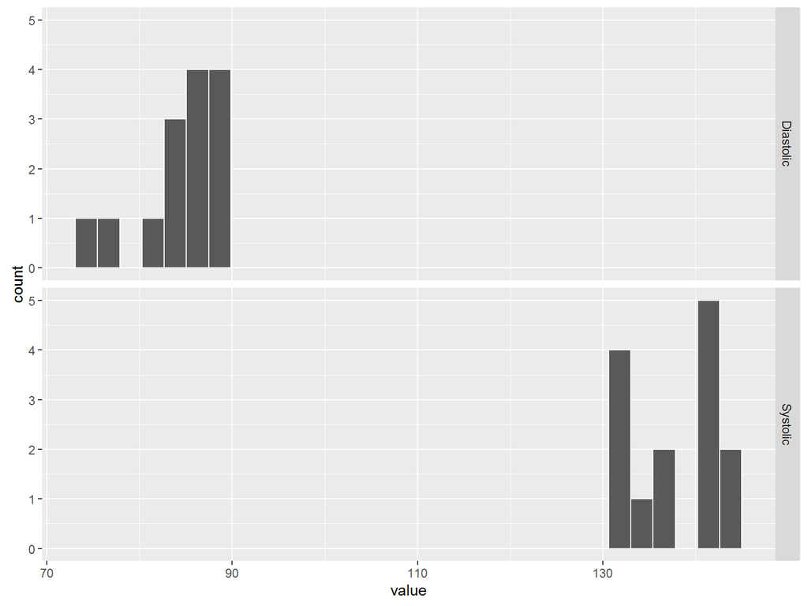

```r
ggplot(data = Ex3_tidy,
       mapping = aes(x = value)) +
  geom_histogram(color = "white") +
  facet_grid(variable ~ .)
```

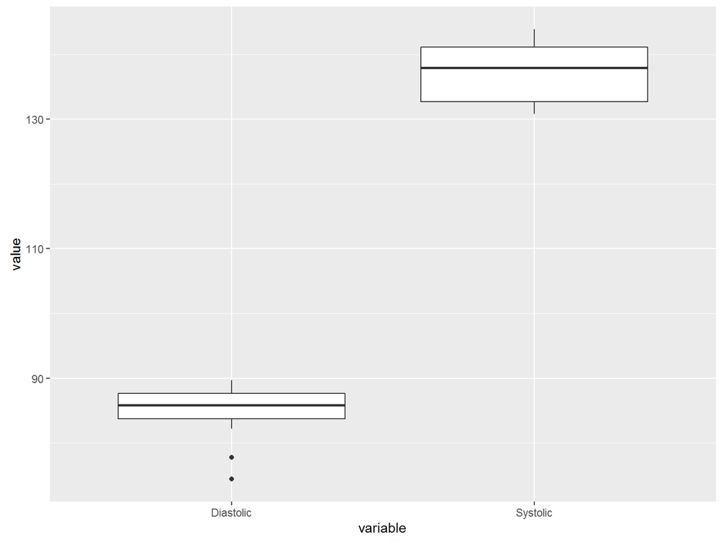

```r
ggplot(data = Ex3_tidy,
       mapping = aes(x = variable,
                     y = value)) +
  geom_boxplot()
```

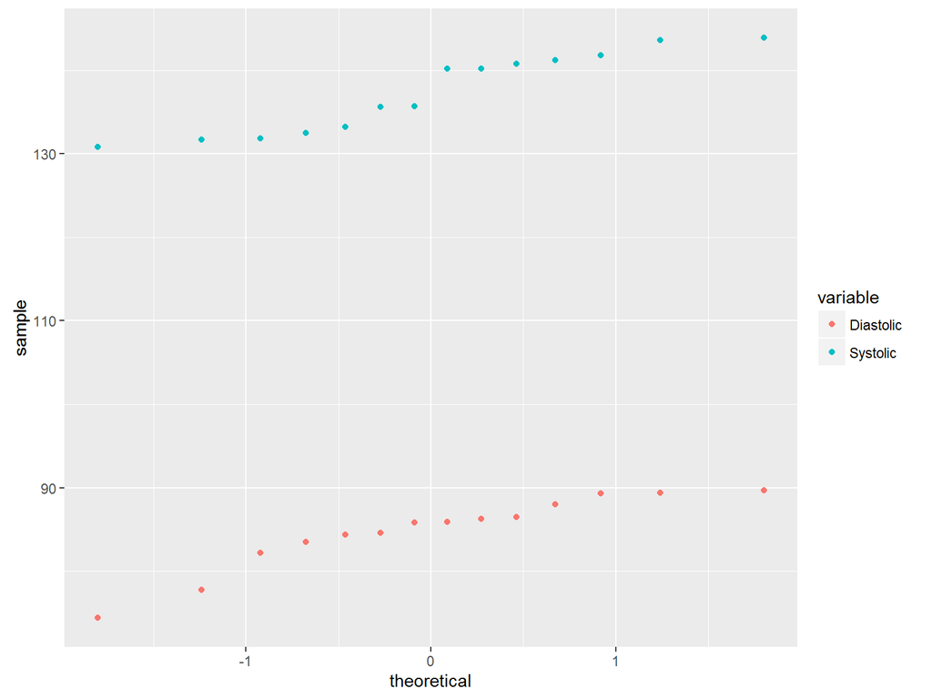

```r
ggplot(data = Ex3_tidy,
       mapping = aes(sample = value,
                     colour = variable)) +
  stat_qq()
```

```r
# Pearson's
with(Ex3, cor.test(Systolic, Diastolic)) %>% tidy()
```

```
##    estimate statistic   p.value parameter   conf.low conf.high
## 1 0.4184442  1.595976 0.1364778        12 -0.1441361 0.7766038
##                                 method alternative
## 1 Pearson's product-moment correlation   two.sided
```

```r
# Spearman's
with(Ex3, cor.test(Systolic, Diastolic, method = "spearman")) %>% tidy()
```

```
##    estimate statistic     p.value                          method
## 1 0.7084713  132.6456 0.004567284 Spearman's rank correlation rho
##   alternative
## 1   two.sided
```

# Regression

Assumptions

- Constant variance
- Residuals distributed as $N(0, \sigma^2)$

# Regression

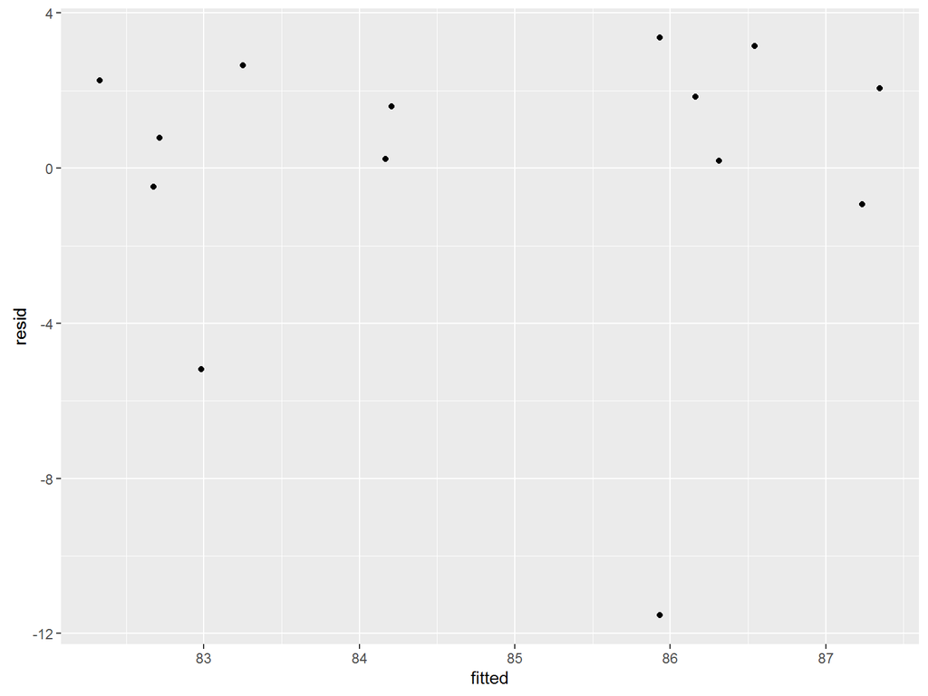

```r
fit <- lm(Diastolic ~ Systolic, data = Ex3)

Ex3 <- Ex3 %>%
  mutate(resid = residuals(fit),
         fitted = fitted(fit))

ggplot(data = Ex3,
       mapping = aes(x = fitted,
                     y = resid)) +
  geom_point()
```

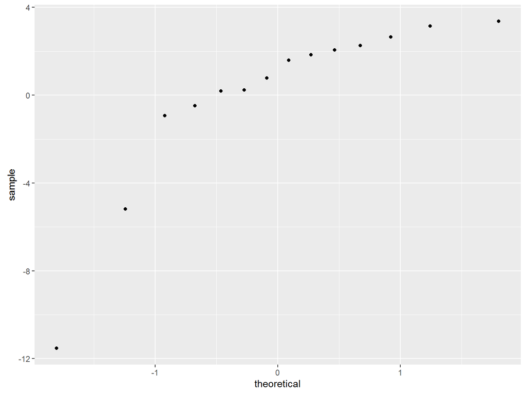

```r
ggplot(data = Ex3,
       mapping = aes(sample = resid)) +
  stat_qq()
```

Oh no! What do we do!?

# Regression

The common practice is to use a transformation. Perhaps a log transformation.

But this can distort the interpretation. Instead of interpreting the slope, we have to interpret a log-slope.

Mathematicians have a hard enough time doing this, let alone the general public.

```r
fit_log <- lm(log(Diastolic) ~ Systolic, data = Ex3)
```

# Regression

Use quantile regression instead.

```r
library(quantreg)
fit_quant <- rq(Diastolic ~ Systolic, data = Ex3)
```

Compare the results

```r
tidy(fit)
```

```
##          term   estimate  std.error statistic   p.value
## 1 (Intercept) 32.2280379 32.9856973 0.9770307 0.3478401
## 2    Systolic  0.3830512  0.2400106 1.5959760 0.1364778
```

```r
tidy(fit_log, exponentiate = TRUE)
```

```
##          term  estimate   std.error statistic      p.value
## 1 (Intercept) 46.119696 0.405031982  9.459105 6.508842e-07
## 2    Systolic  1.004438 0.002947095  1.502638 1.587841e-01
```

```r
tidy(fit_quant)
```

```
##          term   estimate     conf.low  conf.high tau
## 1 (Intercept) 19.2338843 -18.85929956 72.7685664 0.5
## 2    Systolic  0.4876033   0.09916012  0.7873198 0.5
```

# Compare and Contrast

Advantages of going non-parametric

- Less worry about your assumptions
- They tend to be valid analyses regardless of data distribution

Disadvantages

- Less statistical power (only true when parametric procedure are valid)
- sometimes the interpretations aren’t as straight-forward